# Modelo de simulação de implantação do sistema free flow

## Autor: Pedro Caldeira

### Sobre

O modelo de simulação trata-se de uma ferramenta computacional projetada para identificar os impactos advindos da implantação de um sistema de cobrança free flow com objetivo de aumentar a base de pedagiamento e a proporcionalidade de pagamento. Considerando a relevância da Rodovia Presidente Dutra e a sua disponibilidade de dados face a sua recente licitação, optou-se pela construção do modelo tendo como estudo de caso o sistema rodoviário BR-116/101/RJ/SP (Via Dutra e Rio-Santos), atualmente operado pela concessionária CCR RioSP.

O modelo abrange dois modos de operação de praça de pedágio: o modelo de praça de pedágio tradicional e o modelo de cobrança de pedágio de fluxo livre (free flow) com política de preços baseada na distância percorrida.

### Bibliotecas Utilizadas

```r
library(tidyr)
library(dplyr)
library(zoo)
library(readr)
library(ggplot2)
library(shiny)
library(plotly)
library(scales)
library(shinydashboard)
library(DT)
library(shinyWidgets)
library(rhandsontable)
```

## Base de dados

### Tabelas

Para rodar a simulação, substitua os dados nas tabelas listadas abaixo, com dados de qualquer rodovia, obedecendo o formato estabelecido nelas:

“SECTION_DATA.csv” “TRAFFIC_VOLUME_DATA.csv” “TOLL_INFO_CONTRACT.csv” “BENCHMARKINGDATA.csv”

O código abaixo fará a importação dos dados para ajuste do simulador a qualquer rodovia com pedágio:

```r
#Declaração das variáveis

Section_Input <- data.frame()
Traffic_Volume_Input <- data.frame()
Traffic_Axles_Input <- data.frame()
Toll_Info_Contract <- data.frame()
BenchData <- data.frame()

#Importação dos arquivos com dados de rodovias em CSV, conforme o padrão estabelecido

Section_Input <- read.csv("SECTION_DATA.csv", sep = ";", dec = ",")
Traffic_Volume_Input <- read.csv("TRAFFIC_VOLUME_DATA.csv", sep = ";", dec = ",")
Traffic_Axles_Input <- read.csv("TRAFFIC_AXLES_DATA.csv", sep = ";", dec = ",")
Toll_Info_Contract <- read.csv("TOLL_INFO_CONTRACT.csv", sep = ";", dec = ",")
BenchData <- read.csv("BENCHMARKINGDATA.csv", sep = ";", dec = ",")
```

### Tratamento

**Dados das seções de tráfego a partir de “SECTION_DATA”**

```r
#Declaração das variáveis

Road_IDs <- data.frame()
Mainline <- data.frame()
Road_Locations <- data.frame()
Toll_Locations <- data.frame()
num_rows <- 0
contract_year <- 0
Section <- data.frame()
Section_linear <- data.frame()
Road_Directions <- data.frame()
linear_km <- data.frame()
linear_kmC <- data.frame()
linear_kmD <- data.frame()
AcRoad <- 0
FRoadLength <- 0



# Localização de Pedágios e Trechos

Road_IDs <- unique(Section_Input["ROAD_ID"])
Road_IDs$ID_ROAD <- seq(1, nrow(Road_IDs))
Mainline <- unique(Section_Input["MAINLINE"])
Road_Locations <- unique(Section_Input["ROAD_LOCATION"])
Toll_Locations <- Section_Input[c("ROAD_ID","ROAD_LOCATION","START_KM","END_KM","DIRECTION","TOLLZONE","IS_TOLL")]
Toll_Locations <- Toll_Locations[Toll_Locations$IS_TOLL > 0,]
Toll_Locations <- Toll_Locations[order(Toll_Locations$TOLLZONE),]
num_rows <- nrow(Toll_Locations)
contract_year = ncol(Traffic_Axles_Input)
Section <- cbind(IDSeq = seq_along(Section_Input$VOL_COLLECTION_REF), Section_Input)
Section_linear <- subset(Section, Section$MAINLINE == "Mainline")
Section$TOLLZONE <- gsub(" ", "", Section$TOLLZONE)
Section$TOLLZONE <- gsub(" ", "", Section$TOLLZONE)



# Linearização da Rodovia: Converte a referência atual dos marcos quilométricos da rodovia, para iniciarem em 0 no sentido crescente.

linear_km <- unique(subset(Section_linear, select = c("IDSeq","DIRECTION","ROAD_ID", "ROAD_LOCATION", "START_KM", "END_KM","LENGTH")))
linear_km <- merge(linear_km, Road_IDs, by = "ROAD_ID")
linear_km <- linear_km %>% mutate(DIRECTION.X = ifelse(START_KM < END_KM, "C", "D"))
Road_Directions <- linear_km %>% select(DIRECTION, DIRECTION.X) %>% distinct()
linear_kmC <- subset(linear_km, linear_km$DIRECTION.X == "C")
linear_kmC$START_KM <- as.numeric(linear_kmC$START_KM)
linear_kmC <- linear_kmC %>% arrange(ID_ROAD, ROAD_LOCATION, START_KM)
AcRoad <- 0
FRoadLength <- 0
linear_kmC$LENGTH <- linear_kmC$END_KM - linear_kmC$START_KM
linear_kmC$KM_START_lin[1] <- 0

  for (i in 2:nrow(linear_kmC)){
  if (linear_kmC$ID_ROAD[i] == linear_kmC$ID_ROAD[i-1] ) {
    FRoadLength <- linear_kmC$LENGTH[i-1]
    AcRoad <- AcRoad + FRoadLength
    linear_kmC$KM_START_lin[i] <- AcRoad
  } else {
    AcRoad <- 0
    FRoadLength <- 0
    AcRoad <- AcRoad + FRoadLength
    linear_kmC$KM_START_lin[i] <- AcRoad
  }
}
linear_kmD <- subset(linear_km, linear_km$DIRECTION.X == "D")
linear_kmD$START_KM <- as.numeric(linear_kmD$START_KM)
linear_kmD <- linear_kmD %>%
  arrange(ID_ROAD, ROAD_LOCATION, START_KM)
AcRoad <- 0
FRoadLength <- 0
linear_kmD$KM_END_lin <- 0
linear_kmD$LENGTH <- linear_kmD$START_KM - linear_kmD$END_KM
linear_kmD$KM_END_lin[1] <- 0

  for (i in 2:nrow(linear_kmD)){
  if (linear_kmD$ID_ROAD[i] == linear_kmD$ID_ROAD[i-1] ) {
    FRoadLength <- linear_kmD$LENGTH[i-1]
    AcRoad <- AcRoad + FRoadLength
    linear_kmD$KM_END_lin[i] <- AcRoad
  } else {
    AcRoad <- 0
    FRoadLength <- 0
    AcRoad <- AcRoad + FRoadLength
    linear_kmD$KM_END_lin[i] <- AcRoad
  }
}

linear_kmD$KM_START_lin <- linear_kmD$KM_END_lin + linear_kmD$LENGTH
linear_kmC$KM_END_lin <- linear_kmC$KM_START_lin + linear_kmC$LENGTH
linear_kmD <- linear_kmD[, names(linear_kmC)]
linear_km <- rbind(linear_kmD, linear_kmC)

Road_IDs <- select(Road_IDs, ROAD_ID)
Road_IDs <- pull(Road_IDs,"ROAD_ID")
```

**Dados de pedágio e contrato “TOLL_INFO_CONTRACT”**

```r
#Declaração das variáveis

Toll_Info <- data.frame()
Toll_Road_ID <- data.frame()
SectionUnique <- data.frame()


# Informações das Praças de Pedáagio

Toll_Info <- data.frame(
  ID = 1:num_rows,
  Toll_km_Tariff_Multilanes = as.numeric(Toll_Info_Contract$TARIFF_KM_MULTILANES),
  Toll_km_Tariff_Singlelanes = as.numeric(Toll_Info_Contract$TARIFF_KM_SINGLELANES),
  Toll_Actual_Coverage_Extension_Multilanes = as.numeric(Toll_Info_Contract$CURRENT_TOLL_COVERAGE_MULTILANES),
  Toll_Actual_Coverage_Extension_Singlelanes = as.numeric(Toll_Info_Contract$CURRENT_TOLL_COVERAGE_SINGLELANES),
  Toll_Duplicated_Coverage_Extension_Multilanes = as.numeric(Toll_Info_Contract$DUPLICATED_TOLL_COVERAGE_MULTILANES),
  Toll_Duplicated_Coverage_Extension_Singlelanes = as.numeric(Toll_Info_Contract$DUPLICATED_TOLL_COVERAGE_SINGLELANES),
  Duplication_Year = Toll_Info_Contract$DUPLICATED_ROAD_COLLECTION_YEAR,
  Toll_ID = Toll_Info_Contract$TOLL_ID)

Toll_Info$Toll_Tariff_Actual <- Toll_Info$Toll_km_Tariff_Multilanes * Toll_Info$Toll_Actual_Coverage_Extension_Multilanes + Toll_Info$Toll_km_Tariff_Singlelanes * Toll_Info$Toll_Actual_Coverage_Extension_Singlelanes
Toll_Info$Toll_Tariff_Duplicated <- Toll_Info$Toll_km_Tariff_Multilanes * Toll_Info$Toll_Duplicated_Coverage_Extension_Multilanes + Toll_Info$Toll_km_Tariff_Singlelanes * Toll_Info$Toll_Duplicated_Coverage_Extension_Singlelanes

# Informações das Localizações das Praças de Pedágio e TCP

Toll_Road_ID <- Toll_Locations %>%
  select(ROAD_ID, TOLLZONE)
Toll_Road_ID$TOLLZONE <- gsub(" ", "", Toll_Road_ID$TOLLZONE)
Toll_Road_ID$TOLLZONE <- gsub(" ", "", Toll_Road_ID$TOLLZONE)
Toll_Info$TOLLZONE <- gsub(" ", "", Toll_Info$Toll_ID)
Toll_Info$TOLLZONE <- gsub(" ", "", Toll_Info$TOLLZONE)
Toll_Info <- left_join(Toll_Info, Toll_Road_ID, by = "TOLLZONE")

SectionUnique <- unique(subset(Section, select = c("TOLLZONE", "MAINLINE", "TRAFFIC_SECTION")))

for (i in 1:nrow(Toll_Info)){
  Toll_Info$MLSections[i] <- sum(SectionUnique$TOLLZONE == Toll_Info$TOLLZONE[i] & SectionUnique$MAINLINE == "Mainline", na.rm = TRUE)
  Toll_Info$TotalSections[i] <- nrow(subset(SectionUnique, TOLLZONE == Toll_Info$TOLLZONE[i]))
  Toll_Info$SdSections[i] <- Toll_Info$TotalSections[i] - Toll_Info$MLSections[i]
}

Toll_Info$TCP <- Toll_Info$Toll_Actual_Coverage_Extension_Singlelanes + Toll_Info$Toll_Actual_Coverage_Extension_Multilanes
TollTarifYear <- subset(Toll_Info, select = c(TOLLZONE, Duplication_Year, Toll_Tariff_Actual, Toll_Tariff_Duplicated))
```

**Dados de tráfego “TRAFFIC_VOLUME_DATA” e “TRAFFIC_AXLES_DATA”**

```r
#Declaração das variáveis
Traffic_Axles <- data.frame()
Traffic_Volume <- data.frame()
Traffic_Data <- data.frame()

# Bases de Tráfego

Traffic_Axles <- data.frame(Traffic_Axles_Input)
Traffic_Axles <- cbind(IDSeq = seq_along(Traffic_Axles$TRAFFIC_VOL_COLLECTION_POINT), Traffic_Axles)
n <- contract_year + 1
Traffic_Axles <- pivot_longer(Traffic_Axles, cols = 3:n, names_to = "Year", values_to = "Axles_Volume")
Traffic_Axles <- data.frame(IDSeq = Traffic_Axles$IDSeq, VOL_COLLECTION_REF = Traffic_Axles$TRAFFIC_VOL_COLLECTION_POINT,
                                 Year = as.integer(gsub("X", "", Traffic_Axles$Year)),
                                 Axles_Volume = as.integer(Traffic_Axles$Axles_Volume)*365)
Traffic_Axles[is.na(Traffic_Axles)] <- 0

Traffic_Volume <- data.frame(Traffic_Volume_Input)
Traffic_Volume <- cbind(IDSeq = seq_along(Traffic_Volume$TRAFFIC_VOL_COLLECTION_POINT), Traffic_Volume)
Traffic_Volume <- pivot_longer(Traffic_Volume, cols = 3:n, names_to = "Year", values_to = "Traffic_Volume")




Traffic_Volume <- data.frame(IDSeq = Traffic_Volume$IDSeq, VOL_COLLECTION_REF = Traffic_Volume$TRAFFIC_VOL_COLLECTION_POINT,
                                 Year = as.integer(gsub("X", "", Traffic_Volume$Year)),
                                 Traffic_Volume = as.integer(Traffic_Volume$Traffic_Volume)*365)
Traffic_Volume[is.na(Traffic_Volume)] <- 0

Traffic_Data <- left_join(Traffic_Axles, Traffic_Volume, by = c("VOL_COLLECTION_REF","IDSeq", "Year"))
Traffic_Data <- left_join(Traffic_Data, Section, by = c("IDSeq", "VOL_COLLECTION_REF"))
Traffic_Data <- Traffic_Data %>% left_join(TollTarifYear, by = "TOLLZONE")
Traffic_Data$Tariff <- ifelse(Traffic_Data$Year < Traffic_Data$Duplication_Year, Traffic_Data$Toll_Tariff_Actual, Traffic_Data$Toll_Tariff_Duplicated)
Traffic_Data[is.na(Traffic_Data)] <- 0
```

**Outros tratamentos de dados e combinação dos dados**

```r
#Declaração das variáveis

TrafficandTariff <- data.frame()
Traffic_Data_Aux <- data.frame()
Traffic_TradToll <- data.frame()


#Combinação de Tráfego e Tarifa

Traffic_Data_Aux <- Traffic_Data
TrafficandTariff <- subset(Traffic_Data_Aux, select = c("TOLLZONE","IDSeq", "Year", "Axles_Volume", "Traffic_Volume", "Tariff", "ROAD_ID", "MAINLINE"))
TrafficandTariff$Traffic_Volume <- as.numeric(TrafficandTariff$Traffic_Volume)
TrafficandTariff$Axles_Volume <- as.numeric(TrafficandTariff$Axles_Volume)
TrafficandTariff <- unique(TrafficandTariff, by = c("TOLLZONE", "Year"))
TrafficandTariff$TCP <- left_join(TrafficandTariff, Toll_Info, by = "TOLLZONE")$TCP
Traffic_Data_Aux <- left_join(Traffic_Data, linear_km, by = "IDSeq")
Traffic_TradToll <- unique(subset(Traffic_Data_Aux, select = c("IDSeq", "TOLLZONE", "IS_TOLL", "Year", "Axles_Volume", "Traffic_Volume", "Tariff"))) %>%
  arrange(TOLLZONE, Year)
Traffic_TradToll <- filter(Traffic_TradToll, IS_TOLL == 1)
```

**Criação da Matriz de Origem e Destino**

```r
#Declaração das variáveis
ODTradMatrix <- data.frame()
ODTradMatrix_AUX <- matrix(0, nrow = num_rows, ncol = num_rows)
num_rows <- 0


#Base OD Tarifa Tradicional

ODTradMatrix_AUX <- left_join(linear_km, Traffic_TradToll, by = "IDSeq")
ODTradMatrix_AUX$Tariff <- replace(ODTradMatrix_AUX$Tariff, is.na(ODTradMatrix_AUX$Tariff), 0)

ODTradMatrix_AUX <- unique(select(ODTradMatrix_AUX, ROAD_ID, START_KM, END_KM, KM_START_lin, KM_END_lin))

ODTradMatrix_AUX <- ODTradMatrix_AUX %>%
  group_by(ROAD_ID) %>%
  arrange(KM_START_lin)

num_rows <- length(unique(ODTradMatrix_AUX$KM_START_lin))



ODTradMatrix <- matrix(0, nrow = num_rows, ncol = num_rows)
```

### Análise dos Dados

Neste etapa, verificamos se os dados importados estão corretos e prontos para serem utilizados na simulação.

**Dados das seções de tráfego a partir de “SECTION_DATA”**

```r
#Declaração das variáveis
Resumo_linear_km <- data.frame()

#Análise
Resumo_linear_km <- linear_km %>%
  group_by(ROAD_ID, DIRECTION.X) %>%
  summarise(
    Min_START_KM_lin = min(KM_START_lin),
    Max_END_KM_lin = max(KM_END_lin),
    Qty_SH = n(),
    Media_DIST = mean(LENGTH))

#Resultados
datatable(Resumo_linear_km)
```

|  | ROAD_ID | DIRECTION.X | Min_START_KM_lin | Max_END_KM_lin | Qty_SH | Media_DIST |
| --- | --- | --- | --- | --- | --- | --- |
| 1 | BR-101 | C | 0 | 238.5 | 28 | 8.517857142857142 |
| 2 | BR-101 | D | 8.5 | 209.9 | 28 | 8.517857142857142 |
| 3 | BR-116 | C | 0 | 363.7000000000003 | 86 | 4.229069767441861 |
| 4 | BR-116 | D | 8 | 362.6000000000003 | 86 | 4.229069767441861 |

```r
print(Road_IDs)
```

```
## [1] "BR-101" "BR-116"
```

**Dados de pedágio e contrato “TOLL_INFO_CONTRACT”**

```r
#Declaração das variáveis
Resumo_Toll_Info <- data.frame()
Resumo_Toll_Tariff <- data.frame()

#Análise

Resumo_Toll_Info <- summary(Toll_Info)

Resumo_Toll_Info <- Toll_Info %>%
  group_by(TOLLZONE) %>%
  summarise(
    Min_Toll_Tariff_Actual = min(Toll_Tariff_Actual),
    Max_Toll_Tariff_Actual = max(Toll_Tariff_Actual),
    Min_Toll_Tariff_Duplicated = min(Toll_Tariff_Duplicated),
    Max_Toll_Tariff_Duplicated = max(Toll_Tariff_Duplicated),
    Min_Duplication_Year = min(Duplication_Year),
    Max_Duplication_Year = max(Duplication_Year),
    Min_TCP = min(TCP),
    Max_TCP = max(TCP),
    Min_MLSections = min(MLSections),
    Max_MLSections = max(MLSections),
    Min_TotalSections = min(TotalSections),
    Max_TotalSections = max(TotalSections),
    Min_SdSections = min(SdSections),
    Max_SdSections = max(SdSections))

Resumo_Toll_Tariff <- Toll_Info %>%
  group_by(TOLLZONE) %>%
  summarise(
    Min_Toll_Tariff_Actual = min(Toll_Tariff_Actual),
    Max_Toll_Tariff_Actual = max(Toll_Tariff_Actual),
    Min_Toll_Tariff_Duplicated = min(Toll_Tariff_Duplicated),
    Max_Toll_Tariff_Duplicated = max(Toll_Tariff_Duplicated))

#Resultados
datatable(Resumo_Toll_Info)
```

|  | TOLLZONE | Min_Toll_Tariff_Actual | Max_Toll_Tariff_Actual | Min_Toll_Tariff_Duplicated | Max_Toll_Tariff_Duplicated | Min_Duplication_Year | Max_Duplication_Year | Min_TCP | Max_TCP | Min_MLSections | Max_MLSections | Min_TotalSections | Max_TotalSections | Min_SdSections | Max_SdSections |
| --- | --- | --- | --- | --- | --- | --- | --- | --- | --- | --- | --- | --- | --- | --- | --- |
| 1 | P10N | 3.5976112 | 3.5976112 | 3.998376 | 3.998376 | 2031 | 2031 | 83.03999999999999 | 83.03999999999999 | 3 | 3 | 3 | 3 | 0 | 0 |
| 2 | P10S | 3.5976112 | 3.5976112 | 3.998376 | 3.998376 | 2031 | 2031 | 83.03999999999999 | 83.03999999999999 | 3 | 3 | 3 | 3 | 0 | 0 |
| 3 | P1eP2N | 3.242936 | 3.242936 | 3.242936 | 3.242936 | 2053 | 2053 | 32.8 | 32.8 | 5 | 5 | 8 | 8 | 3 | 3 |
| 4 | P1eP2S | 3.242936 | 3.242936 | 3.242936 | 3.242936 | 2053 | 2053 | 32.8 | 32.8 | 5 | 5 | 8 | 8 | 3 | 3 |
| 5 | P3N | 3.242936 | 3.242936 | 3.242936 | 3.242936 | 2053 | 2053 | 32.8 | 32.8 | 2 | 2 | 3 | 3 | 1 | 1 |
| 6 | P3S | 3.242936 | 3.242936 | 3.242936 | 3.242936 | 2053 | 2053 | 32.8 | 32.8 | 2 | 2 | 3 | 3 | 1 | 1 |
| 7 | P4eP5N | 5.872878 | 5.872878 | 5.872878 | 5.872878 | 2053 | 2053 | 59.4 | 59.4 | 5 | 5 | 6 | 6 | 1 | 1 |
| 8 | P4eP5S | 5.872878 | 5.872878 | 5.872878 | 5.872878 | 2053 | 2053 | 59.4 | 59.4 | 5 | 5 | 6 | 6 | 1 | 1 |
| 9 | P6N | 12.2707557 | 12.2707557 | 12.2707557 | 12.2707557 | 2053 | 2053 | 124.11 | 124.11 | 15 | 15 | 15 | 15 | 0 | 0 |
| 10 | P6S | 12.2707557 | 12.2707557 | 12.2707557 | 12.2707557 | 2053 | 2053 | 124.11 | 124.11 | 15 | 15 | 15 | 15 | 0 | 0 |

[output cut: 6 more lines]

```r
datatable(Resumo_Toll_Tariff)
```

|  | TOLLZONE | Min_Toll_Tariff_Actual | Max_Toll_Tariff_Actual | Min_Toll_Tariff_Duplicated | Max_Toll_Tariff_Duplicated |
| --- | --- | --- | --- | --- | --- |
| 1 | P10N | 3.5976112 | 3.5976112 | 3.998376 | 3.998376 |
| 2 | P10S | 3.5976112 | 3.5976112 | 3.998376 | 3.998376 |
| 3 | P1eP2N | 3.242936 | 3.242936 | 3.242936 | 3.242936 |
| 4 | P1eP2S | 3.242936 | 3.242936 | 3.242936 | 3.242936 |
| 5 | P3N | 3.242936 | 3.242936 | 3.242936 | 3.242936 |
| 6 | P3S | 3.242936 | 3.242936 | 3.242936 | 3.242936 |
| 7 | P4eP5N | 5.872878 | 5.872878 | 5.872878 | 5.872878 |
| 8 | P4eP5S | 5.872878 | 5.872878 | 5.872878 | 5.872878 |
| 9 | P6N | 12.2707557 | 12.2707557 | 12.2707557 | 12.2707557 |
| 10 | P6S | 12.2707557 | 12.2707557 | 12.2707557 | 12.2707557 |

[output cut: 6 more lines]

**Dados de tráfego “TRAFFIC_VOLUME_DATA” e “TRAFFIC_AXLES_DATA”**

```r
#Declaração das variáveis
Resumo_Traffic_Data <- data.frame()
Resumo_Traffic_Volume <- data.frame()
Resumo_Traffic_Axles <- data.frame()


#Análise
Resumo_Traffic_Data <- Traffic_Data %>%
  group_by(ROAD_ID, Year) %>%
  summarise(
    Min_Axles_Volume = min(Axles_Volume),
    Max_Axles_Volume = max(Axles_Volume),
    Mean_Axl_Volume = mean(Axles_Volume),
    Min_Traffic_Volume = min(Traffic_Volume),
    Max_Traffic_Volume = max(Traffic_Volume),
    Mean_Traffic_Volume = mean(Traffic_Volume))

Traffic_Curve <- Traffic_Data %>%
  group_by(ROAD_ID, Year) %>%
  summarise(
    sum_Axles_Volume = sum(Axles_Volume))

# Resultados
datatable(Resumo_Traffic_Data)
```

|  | ROAD_ID | Year | Min_Axles_Volume | Max_Axles_Volume | Mean_Axl_Volume | Min_Traffic_Volume | Max_Traffic_Volume | Mean_Traffic_Volume |
| --- | --- | --- | --- | --- | --- | --- | --- | --- |
| 1 | BR-101 | 2018 | 305140 | 2103860 | 1222912.946428571 | 273385 | 1862960 | 1093005.535714286 |
| 2 | BR-101 | 2019 | 307695 | 2120285 | 1232448.571428571 | 275575 | 1876465 | 1101055.089285714 |
| 3 | BR-101 | 2020 | 313900 | 2162990 | 1257275.089285714 | 280685 | 1912235 | 1121970.892857143 |
| 4 | BR-101 | 2021 | 313170 | 2211170 | 1282935.892857143 | 278860 | 1952020 | 1142867.142857143 |
| 5 | BR-101 | 2022 | 312805 | 2260080 | 1296010.714285714 | 277400 | 1992535 | 1151183.928571429 |
| 6 | BR-101 | 2023 | 316820 | 2308990 | 1322792.589285714 | 279955 | 2033050 | 1173070.892857143 |
| 7 | BR-101 | 2024 | 328865 | 2360820 | 1353296.160714286 | 290905 | 2075755 | 1198646.964285714 |
| 8 | BR-101 | 2025 | 340180 | 2413745 | 1384972.946428571 | 300760 | 2119555 | 1225109.464285714 |
| 9 | BR-101 | 2026 | 348210 | 2469225 | 1416649.732142857 | 307330 | 2164815 | 1251220 |
| 10 | BR-101 | 2027 | 356605 | 2527260 | 1449532.321428571 | 314265 | 2212630 | 1278334.285714286 |

[output cut: 62 more lines]

```
## Error : The fig.showtext code chunk option must be TRUE
```

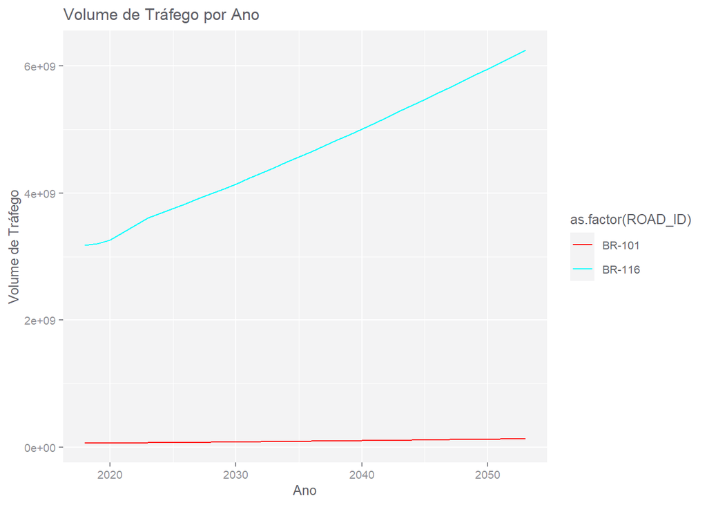

```r
# Criando um vetor de cores para cada ROAD_ID
cores <- rainbow(length(unique(Traffic_Curve$ROAD_ID)))

# Criando o gráfico com cores diferentes para cada ROAD_ID
ggplot(data = Traffic_Curve, aes(x = Year, y = sum_Axles_Volume, color = as.factor(ROAD_ID))) +
  geom_line() +
  labs(x = "Ano", y = "Volume de Tráfego", title = "Volume de Tráfego por Ano") +
  scale_color_manual(values = cores)
```

```
## Error : The fig.showtext code chunk option must be TRUE
```

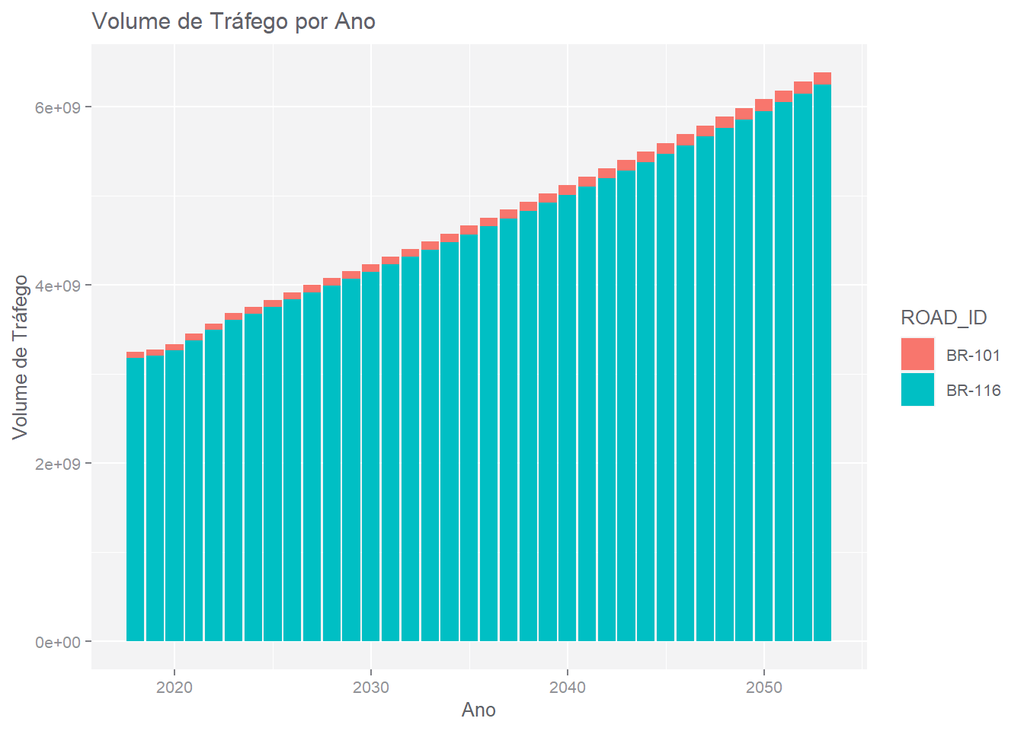

```r
# Criando o gráfico de barras comparáveis para cada ROAD_ID
ggplot(data = Traffic_Curve, aes(x = Year, y = sum_Axles_Volume, fill = as.factor(ROAD_ID))) +
  geom_bar(stat = "identity") +
  labs(x = "Ano", y = "Volume de Tráfego", title = "Volume de Tráfego por Ano") +
  scale_fill_discrete(name = "ROAD_ID")
```

## Simulação

```r
# Definir os parâmetros de entrada

  StartYear <- 2022
  EndYear <- 2052
  inputRoad <- "BR-116"
  SLane = "yes"
  Lane =     if (SLane == "yes") {"Mainline and Side Lane"} else {"Mainline Only"}
  WACC <- 0.0847
  Revenue_Taxes <- 0.0865
  Income_Taxes <- 0.34
  TradOBU <- 0.75
  TradEvasion <- 0.01
  inv_trad <- "yes"
  TCAPEX <-  8266766.42
  TREPEX <-  900392.57
  TREPEX_Freq <- 8
  FFOBU <- 0.8
  FFCAPEX <-  1351663.25
  FFREPEX <-  675831.63
  FFREPEX_Freq <- 5
  TFixCost <- 0
  FfixCost <- 0
  SCENARIO = "S1"
  S1 = ifelse(SCENARIO == "S1", 1, 0)
  S2 = ifelse(SCENARIO == "S2", 1, 0)
  S3 = ifelse(SCENARIO == "S3", 1, 0)
  S4 = ifelse(SCENARIO == "S4", 1, 0)
  costTDcash <-  0.06 * 4.176988667 * S1 + 0.29 * 4.176988667 * S2 + 0.29 * 4.176988667 * S3 + 0.06 * 4.176988667 * S4
  costTDOBU <-  0.06 * 4.176988667 * S1 + 0.15 * 4.176988667 * S2 + 0.15 * 4.176988667 * S3 + 0.15 * 4.176988667 * S4
  costFFVideo <- 0.24 * 4.176988667 * S1 + 0.31 * 4.176988667 * S2 + 0.31 * 4.176988667 * S3 + 0.31 * 4.176988667 * S4
  SCENARIOLEAK = SCENARIO
  S1E = ifelse(SCENARIOLEAK == "S1", 1, 0)
  S2E = ifelse(SCENARIOLEAK == "S2", 1, 0)
  S3E = ifelse(SCENARIOLEAK == "S3", 1, 0)
  S4E = ifelse(SCENARIOLEAK == "S4", 1, 0)
  FFEvasion <- 0.035 * S1E + 0.045 * S2E + 0.09 * S3E + 0.15 * S4E
  costENFF <-  0
  cost_target <- 0.05
  cost_eff <- "linear"
  leak_target <- 0.00
  leak_eff <- "linear"
  fosimulation <- "Maximize Revenue"
  ecbalance <- "Toll NPV"
  sensitivityPercCost <- 0.05
  sensitivityPercLeak <- 0.01

  leakcurve <- function(StartYear, EndYear, leak_eff, leak_target) {
  leak_eff_curve <- data.frame(Year = seq(StartYear, EndYear, by = 1),
  Leak_Multiplier = if (leak_eff == "linear") {seq(1, 1-leak_target, length.out = EndYear - StartYear + 1)} else {1 - exp(-seq(1, 1-leak_eff, length.out = EndYear - StartYear + 1))})}

  costcurve <- function(StartYear, EndYear, cost_eff, cost_target) {
  cost_eff_curve <- data.frame(
  Year = seq(StartYear, EndYear, by = 1),
  Cost_Multiplier = if (cost_eff == "linear") {seq(1, 1-cost_target, length.out = EndYear - StartYear + 1)} else {1 - exp(-seq(1, c1-cost_target, length.out = EndYear - StartYear + 1))})}

  leak_eff_curve <- leakcurve(StartYear, EndYear, leak_eff, leak_target)
  cost_eff_curve <- costcurve(StartYear, EndYear, cost_eff, cost_target)

  Toll_Select <- filter(Toll_Info, ROAD_ID == inputRoad)
  num_rows <- length(Toll_Select$TOLLZONE)
  inputDF <- read.csv("TOLL_CONVERSION.csv", sep = ";", dec = ",")
  inputDF$Toll_Tariff_Actual <- as.numeric(inputDF$Toll_Tariff_Actual)
  inputDF$Toll_Tariff_Duplicated <- as.numeric(inputDF$Toll_Tariff_Duplicated)
  inputDF$TCP <- as.numeric(inputDF$TCP)
  inputDF$Average_collection_distance <- as.numeric(inputDF$Average_collection_distance)
SensitivityDF = function(sensitivityPercCost, sensitivityPercLeak) {
Sensitivity <- data.frame(CostSensitivity = c(1, 1 + sensitivityPercCost, 1 - sensitivityPercCost), LeakSensitivity = c(1, 1 + sensitivityPercLeak, 1 - sensitivityPercLeak), Description = c("Base Case", "+ %var", "-% var"))}

Sensitivity <- SensitivityDF(sensitivityPercCost, sensitivityPercLeak)

SensCost = 1
SensLeak = 1
```

### Cálculo

**Praça Tradicional**

```r
# Praça Tradicional

  BaseCase_Simulation <- function(TrafficandTariff, inputRoad, StartYear, EndYear, WACC, Revenue_Taxes, Income_Taxes, TradOBU, TradEvasion, costTDcash, costTDOBU, TFixCost, inv_trad, TCAPEX, TREPEX, TREPEX_Freq, leak_eff_curve, cost_eff_curve) {

  Trad_simulation <- select(TrafficandTariff, TOLLZONE, IDSeq, Year, Axles_Volume, Traffic_Volume, Tariff, ROAD_ID, TCP) %>%
    filter(Year >= StartYear & Year <= EndYear)

  Trad_simulation <- select(Trad_simulation, TOLLZONE, IDSeq, Year, Axles_Volume, Traffic_Volume, Tariff, ROAD_ID, TCP) %>%
    filter(ROAD_ID == inputRoad)

  Trad_simulation <- distinct(Trad_simulation, TOLLZONE, Year, .keep_all = TRUE)

  Trad_simulation$km_Tariff <- Trad_simulation$Tariff / Trad_simulation$TCP

  Trad_simulation$Leak_Curve <- left_join(Trad_simulation, leak_eff_curve, by = "Year")$Leak_Multiplier

  Trad_simulation$GrossRevenue <- Trad_simulation$Axles_Volume * Trad_simulation$Tariff * (1 - TradEvasion * Trad_simulation$Leak_Curve)

  Trad_simulation$NetRevenue <- Trad_simulation$GrossRevenue * (1-Revenue_Taxes)

  Trad_simulation$VariableCost <- costTDcash * Trad_simulation$Traffic_Volume * (1-TradOBU) + costTDOBU * Trad_simulation$Traffic_Volume * TradOBU

  Trad_simulation$FixedCost <- TFixCost

  Trad_simulation$Cost_Curve <- left_join(Trad_simulation, cost_eff_curve, by = "Year")$Cost_Multiplier

  Trad_simulation$TotlCost <- (Trad_simulation$VariableCost + Trad_simulation$FixedCost) * Trad_simulation$Cost_Curve

  Trad_simulation$OperationalProfit <- Trad_simulation$NetRevenue - Trad_simulation$TotlCost

  Trad_simulation$Investment <- ifelse(Trad_simulation$Year == StartYear, TCAPEX, 0)

  Trad_simulation$Reinvestment <- ifelse(Trad_simulation$Year %in% seq(StartYear + TREPEX_Freq, EndYear, by = TREPEX_Freq), TREPEX, 0)

  Trad_simulation$Depreciation <- ifelse(Trad_simulation$Year < StartYear + TREPEX_Freq, TCAPEX / TREPEX_Freq, TREPEX / TREPEX_Freq)

  Trad_simulation$TotalCapex <- if (inv_trad == "yes") {
    Trad_simulation$Investment + Trad_simulation$Reinvestment
  } else {
    0
  }


  Trad_simulation$CashFlow <- Trad_simulation$OperationalProfit - Trad_simulation$TotalCapex - (Trad_simulation$OperationalProfit - Trad_simulation$Depreciation)* Income_Taxes

  Trad_simulation$NetCashFlow <- Trad_simulation$CashFlow / ((1 + WACC)^(Trad_simulation$Year - StartYear))

  Trad_simulation$IncomeTaxes <- (Trad_simulation$OperationalProfit - Trad_simulation$Depreciation)* Income_Taxes
  Trad_simulation$RevenueTaxes <- Trad_simulation$GrossRevenue * Revenue_Taxes

    return(Trad_simulation)



  }
```

**Free Flow sem Equilíbrio Econômico**

```r
# Free Flow sem Equilíbrio Econômico

Generate_Free_Flow_Simulation <- function(inputDF, inputRoad, StartYear, EndYear, WACC, Revenue_Taxes, Income_Taxes, FFEvasion, FFOBU, costFFVideo, costTDOBU, costENFF, FfixCost, FFCAPEX, FFREPEX, FFREPEX_Freq, sensitivityPercCost, sensitivityPercLeak, leak_target, leak_eff, cost_target, cost_eff, fosimulation, ecbalance, SLane) {


  FF_simulation <- select(TrafficandTariff, TOLLZONE, IDSeq, Year, Axles_Volume, Traffic_Volume, Tariff, ROAD_ID, MAINLINE) %>%
    filter(Year >= StartYear & Year <= EndYear)

  if (SLane == "no") {
    FF_simulation <- select(FF_simulation, TOLLZONE, IDSeq, Year, Axles_Volume, Traffic_Volume, Tariff, ROAD_ID, MAINLINE) %>%
    filter(MAINLINE == "Mainline")
  } else {
    FF_simulation <- select(FF_simulation, TOLLZONE, IDSeq, Year, Axles_Volume, Traffic_Volume, Tariff, ROAD_ID, MAINLINE) %>%
    filter(MAINLINE == "Mainline" | MAINLINE == "Side Lane")
  }

  FF_simulation <- select(FF_simulation, TOLLZONE, IDSeq, Year, Axles_Volume, Traffic_Volume, Tariff, ROAD_ID, MAINLINE) %>%
    filter(ROAD_ID == inputRoad)

  TCP = data.frame(TCP = Toll_Select$Toll_Actual_Coverage_Extension_Singlelanes + Toll_Select$Toll_Actual_Coverage_Extension_Multilanes, TOLLZONE = Toll_Select$TOLLZONE)

  FF_simulation$TCP <- left_join(FF_simulation, TCP, by = "TOLLZONE")$TCP

  FF_simulation$km_Tariff <- FF_simulation$Tariff / FF_simulation$TCP

  NewTCP <- data.frame(NewTCP = inputDF$Average_collection_distance, TOLLZONE = inputDF$Toll_Plaza)

  KeepToll <- data.frame(Convert = inputDF$Convert_to_ORT, TOLLZONE = inputDF$Toll_Plaza)

  FF_simulation$NewTCP <- left_join(FF_simulation, NewTCP, by = "TOLLZONE")$NewTCP
  FF_simulation$Convert <- left_join(FF_simulation, KeepToll, by = "TOLLZONE")$Convert

  FF_simulation_Convert <- filter(FF_simulation, Convert == "Yes")

  FF_simulation_Convert$Tariff <- FF_simulation_Convert$km_Tariff * FF_simulation_Convert$NewTCP

  FF_simulation_KeepToll <- filter(FF_simulation, Convert == "No")
  FF_simulation_KeepToll <- distinct(FF_simulation_KeepToll, TOLLZONE, Year, .keep_all = TRUE)

  FF_simulation <- rbind(FF_simulation_Convert, FF_simulation_KeepToll)

  FF_simulation$Leak_Curve <- left_join(FF_simulation, leak_eff_curve, by = "Year")$Leak_Multiplier

  FF_simulation$GrossRevenue <- FF_simulation$Axles_Volume * FF_simulation$Tariff * (1-FFEvasion * FF_simulation$Leak_Curve)

  FF_simulation$NetRevenue <- FF_simulation$GrossRevenue * (1-Revenue_Taxes)

  FF_simulation$VariableCost <- costFFVideo * FF_simulation$Traffic_Volume * (1-FFOBU) + costTDOBU *  FF_simulation$Traffic_Volume * FFOBU + costENFF * FF_simulation$Traffic_Volume * FFEvasion * FF_simulation$Leak_Curve

  FF_simulation$FixedCost <- FfixCost

  FF_simulation$Cost_Curve <- left_join(FF_simulation, cost_eff_curve, by = "Year")$Cost_Multiplier

  FF_simulation$TotlCost <- (FF_simulation$VariableCost + FF_simulation$FixedCost) * FF_simulation$Cost_Curve

  FF_simulation$OperationalProfit <- FF_simulation$NetRevenue - FF_simulation$TotlCost

  FF_simulation$Investment <- ifelse(FF_simulation$Year == StartYear, FFCAPEX, 0)

  FF_simulation$Reinvestment <- ifelse(FF_simulation$Year %in% seq(StartYear + FFREPEX_Freq, EndYear, by = FFREPEX_Freq), FFREPEX, 0)

  FF_simulation$TotalCapex <- if (inv_trad == "yes") {
    FF_simulation$Investment + FF_simulation$Reinvestment
  } else {
    0
  }

  FF_simulation$CashFlow <- FF_simulation$OperationalProfit * (1- Income_Taxes) - FF_simulation$TotalCapex

  FF_simulation$NetCashFlow <- FF_simulation$CashFlow / ((1 + WACC)^(FF_simulation$Year - StartYear))

  FF_simulation$IncomeTaxes <- FF_simulation$OperationalProfit * Income_Taxes
  FF_simulation$RevenueTaxes <- FF_simulation$GrossRevenue * Revenue_Taxes

  return(FF_simulation)
  }
```

**Função de Calculo do Equilíbrio**

```r
  #Função de Calculo do Equilíbrio


  simulation_calc <- function(Tariff_multiplier, FF_simulation, WACC, Revenue_Taxes, Income_Taxes, StartYear, SensCost, SensLeak, SLane) {

  FF_simulation_EB <- subset(FF_simulation, select = c("IDSeq","TOLLZONE", "Year", "Axles_Volume", "Traffic_Volume", "Tariff", "ROAD_ID", "TotalCapex", "MAINLINE"))

  if (SLane == "no") {
    FF_simulation_EB <- select(FF_simulation_EB, TOLLZONE, IDSeq, Year, Axles_Volume, Traffic_Volume, Tariff, ROAD_ID,  TotalCapex, MAINLINE) %>%
    filter(MAINLINE == "Mainline")
  } else {
    FF_simulation_EB <- select(FF_simulation_EB, TOLLZONE, IDSeq, Year, Axles_Volume, Traffic_Volume, Tariff, ROAD_ID, TotalCapex, MAINLINE) %>%
    filter(MAINLINE == "Mainline" | MAINLINE == "Side Lane")
  }

  FF_simulation_EB$Tariff <- FF_simulation$Tariff * Tariff_multiplier

  FF_simulation_EB$km_Tariff <- FF_simulation$km_Tariff  * Tariff_multiplier

  FF_simulation_EB$Leak_Curve <- left_join(FF_simulation_EB, leak_eff_curve, by = "Year")$Leak_Multiplier

  FF_simulation_EB$TotlCost <- (FF_simulation$TotlCost * SensCost)

  FF_simulation_EB$GrossRevenue <- FF_simulation_EB$Axles_Volume * FF_simulation_EB$Tariff * (1-FFEvasion * FF_simulation_EB$Leak_Curve) * SensLeak

  FF_simulation_EB$NetRevenue <- FF_simulation_EB$GrossRevenue * (1-Revenue_Taxes)

  FF_simulation_EB$OperationalProfit <- FF_simulation_EB$NetRevenue - FF_simulation_EB$TotlCost

  FF_simulation_EB$CashFlow <- FF_simulation_EB$OperationalProfit * (1- Income_Taxes) - FF_simulation_EB$TotalCapex

  FF_simulation_EB$NetCashFlow <- FF_simulation_EB$CashFlow / ((1 + WACC)^(FF_simulation_EB$Year - StartYear))

  FF_NPV_EB <- sum(FF_simulation_EB$NetCashFlow)

  FF_simulation_EB$IncomeTaxes <- FF_simulation_EB$OperationalProfit * Income_Taxes
  FF_simulation_EB$RevenueTaxes <- FF_simulation_EB$GrossRevenue * Revenue_Taxes

  list <- list(FF_NPV_EB, FF_simulation_EB)

  return(list)}
```

**Função para zerar o VPL (apoio para restrição de equilíbrio econômico)**

```r
  #Função para zerar o VPL
  optimized_tariff_multiplier <- function(Trad_NPV, Initial_Tariff_multiplier) {

    upper_bound <- Initial_Tariff_multiplier * 1.3
    lower_bound <- 0
    tolerance <- 0.01
    max_tolerance <- 1
    target_npv <- Trad_NPV
    num_iteracoes <- 0
    max_iteracoes <- 100
    Tariff_multiplier <- Initial_Tariff_multiplier

    NPV <- simulation_calc(Tariff_multiplier, FF_simulation, WACC, Revenue_Taxes, Income_Taxes, StartYear, SensCost, SensLeak, SLane)[[1]]

 while (abs(NPV - Trad_NPV) > tolerance) {
    Tariff_multiplier <- (upper_bound + lower_bound) / 2
    NPV <- simulation_calc(Tariff_multiplier, FF_simulation, WACC, Revenue_Taxes, Income_Taxes, StartYear, SensCost, SensLeak, SLane)[[1]]

    if (NPV < Trad_NPV) {
      lower_bound <- Tariff_multiplier
    } else {
      upper_bound <- Tariff_multiplier
    }

    # Aumenta a tolerância após um certo número de iterações
    num_iteracoes <- num_iteracoes + 1
    if (num_iteracoes >= 50) {
      tolerance <- 10*tolerance
    }

    if (tolerance > max_tolerance || num_iteracoes >= max_iteracoes) {
      cat("Interrompendo o loop: tolerância máxima atingida ou número máximo de iterações alcançado.\n")
      break
    }
  }

  return(Tariff_multiplier)
  }
```

**Função para calcular o tarifa de reequilíbrio**

```r
#Função para calcular o tarifa de reequilíbrio

tariff_ecbalance <- function(ecbalance, Trad_NPV) {

  Var_Revenue <- sum(FF_simulation$GrossRevenue)/sum(Trad_simulation$GrossRevenue)
  Var_Profit <- sum(FF_simulation$OperationalProfit)/sum(Trad_simulation$OperationalProfit)

  if(ecbalance == "Toll NPV") {

  Initial_Tariff_multiplier <- 1
  Tariff_multiplier <- optimized_tariff_multiplier(Trad_NPV, Initial_Tariff_multiplier) } else {
  Tariff_multiplier
      if (ecbalance == "Toll Tariff") {
      Tariff_multiplier <- 1} else {

          if (ecbalance == "Toll Revenue") {
          Tariff_multiplier <- 1/Var_Revenue} else {

              if (ecbalance == "Toll Profit") {
              Tariff_multiplier <- 1/Var_Profit} else {
              }
         }
      }
  }
}
```

**Análises de Sensibilidade**

```r
#Análises de Sensibilidade

simulate_sensibility <- function(Sensitivity, FF_simulation, WACC, Revenue_Taxes, Income_Taxes, StartYear, SensCost, SensLeak) {

num_rows = length(Sensitivity)
num_rows
values <- num_rows * num_rows
obfun <- fosimulation
rest <- ecbalance
scenario_Cost <- c("Base", "Cost +", "Cost -")
scenarion_Leak <- c("Base", "Leak +", "Leak -")
counter = 0

data.results <- data.frame(scenario = character(values),
                           revenue = numeric(values),
                           opex = numeric(values),
                           profit = numeric(values),
                           capex = numeric(values),
                           npv = numeric(values),
                           dtresults = numeric(values))

for (i in 1:num_rows) {
  SensCost <- Sensitivity$CostSensitivity[i]
  scenarion_name <- paste(ifelse(SensCost != 1,SensCost,""),scenario_Cost[i], sep = " ")

  for (j in 1:num_rows) {
  scenario_subname <- paste(ifelse(SensLeak != 1, SensLeak,""),scenarion_Leak[j], sep = " ")
  SensLeak <- Sensitivity$LeakSensitivity[j]

  FF_ <- simulation_calc(Tariff_multiplier, FF_simulation, WACC, Revenue_Taxes, Income_Taxes, StartYear, SensCost, SensLeak, SLane)[[2]]

  FF_Revenue_EB <- sum(FF_$GrossRevenue)
  FF_OPEX_EB <- sum(FF_$TotlCost)
  FF_Profit_EB <- sum(FF_$OperationalProfit)
  FF_CAPEX_EB <- sum(FF_simulation_EB$TotalCapex)
  FF_NPV_EB <- sum(FF_$NetCashFlow)

  counter <- counter + 1

  data.results$scenario[counter] <- paste(obfun, rest, scenarion_name, scenario_subname, sep = " ")
  data.results$revenue[counter] <- FF_Revenue_EB
  data.results$opex[counter] <- FF_OPEX_EB
  data.results$profit[counter] <- FF_Profit_EB
  data.results$capex[counter] <- FF_CAPEX_EB
  data.results$npv[counter] <- FF_NPV_EB

  data.results$dtresults[counter] <- FF_

  assign(paste("FF_", obfun, "_", rest, "_",scenarion_name,"_",scenario_subname, sep = ""), FF_)

  SensCost = 1
  SensLeak = 1
}}
}
```

### Resultados

**Simulação**

```r
Trad_simulation <- BaseCase_Simulation(TrafficandTariff, inputRoad, StartYear, EndYear, WACC, Revenue_Taxes, Income_Taxes, TradOBU, TradEvasion, costTDcash, costTDOBU, TFixCost, inv_trad, TCAPEX, TREPEX, TREPEX_Freq, leak_eff_curve, cost_eff_curve)

Trad_NPV <- sum(Trad_simulation$NetCashFlow)

FF_simulation <- Generate_Free_Flow_Simulation(inputDF, inputRoad, StartYear, EndYear, WACC, Revenue_Taxes, Income_Taxes, FFEvasion, FFOBU, costFFVideo, costTDOBU, costENFF, FfixCost, FFCAPEX, FFREPEX, FFREPEX_Freq, sensitivityPercCost, sensitivityPercLeak, leak_target, leak_eff, cost_target, cost_eff, fosimulation, ecbalance, SLane)

Tariff_multiplier <- tariff_ecbalance(ecbalance, Trad_NPV)

FF_simulation_EB <- simulation_calc(Tariff_multiplier, FF_simulation, WACC, Revenue_Taxes, Income_Taxes, StartYear, SensCost, SensLeak, SLane)[[2]]

Sens_Analysis <- simulate_sensibility(Sensitivity, FF_simulation, WACC, Revenue_Taxes, Income_Taxes, StartYear, SensCost, SensLeak)
  # Resultados

  Trad_Profit <- sum(Trad_simulation$OperationalProfit)
  Trad_Revenue <- sum(Trad_simulation$GrossRevenue)
  Trad_CAPEX <- sum(Trad_simulation$TotalCapex)
  Trad_OPEX <- sum(Trad_simulation$TotlCost)
  Trad_kmTariff <- mean(Trad_simulation$km_Tariff)
  Trad_IncomeTaxes <- sum(Trad_simulation$IncomeTaxes)
  Trad_RevenueTaxes <- sum(Trad_simulation$RevenueTaxes)

  FF_NPV <- sum(FF_simulation$NetCashFlow)
  FF_Profit <- sum(FF_simulation$OperationalProfit)
  FF_Revenue <- sum(FF_simulation$GrossRevenue)
  FF_OPEX <- sum(FF_simulation$TotlCost)
  FF_CAPEX <- sum(FF_simulation$TotalCapex)
  FF_kmTariff <- mean(FF_simulation$km_Tariff)
  FF_IncomeTaxes <- sum(FF_simulation$IncomeTaxes)
  FF_RevenueTaxes <- sum(FF_simulation$RevenueTaxes)

  FF_NPV_EB <- sum(FF_simulation_EB$NetCashFlow)
  FF_Profit_EB <- sum(FF_simulation_EB$OperationalProfit)
  FF_Revenue_EB <- sum(FF_simulation_EB$GrossRevenue)
  FF_OPEX_EB <- sum(FF_simulation_EB$TotlCost)
  FF_CAPEX_EB <- sum(FF_simulation_EB$TotalCapex)
  FF_kmTariff_EB <- mean(FF_simulation_EB$km_Tariff)
  FF_IncomeTaxes_EB <- sum(FF_simulation_EB$IncomeTaxes)
  FF_RevenueTaxes_EB <- sum(FF_simulation_EB$RevenueTaxes)

  FF_kmTariffList <- data.frame(IDSeq = FF_simulation_EB$IDSeq, kmTariff = FF_simulation_EB$km_Tariff)

  Var_Revenue <- sum(FF_simulation$GrossRevenue)/sum(Trad_simulation$GrossRevenue)-1
  Var_Profit <- sum(FF_simulation$OperationalProfit)/sum(Trad_simulation$OperationalProfit)-1
  Var_OPEX <- sum(FF_simulation$TotlCost)/sum(Trad_simulation$TotlCost)-1
  Var_CAPEX <- sum(FF_simulation$TotalCapex)/sum(Trad_simulation$TotalCapex)-1
  Var_NPV <- sum(FF_simulation$NetCashFlow)/sum(Trad_simulation$NetCashFlow)-1
  Var_kmTariff <- (FF_kmTariff/Trad_kmTariff)-1
  Var_IncomeTaxes <- sum(FF_simulation$IncomeTaxes)/sum(Trad_simulation$IncomeTaxes)-1
  Var_RevenueTaxes <- sum(FF_simulation$RevenueTaxes)/sum(Trad_simulation$RevenueTaxes)-1


  Var_Revenue_EB <- sum(FF_simulation_EB$GrossRevenue)/sum(Trad_simulation$GrossRevenue)-1
  Var_Profit_EB <- sum(FF_simulation_EB$OperationalProfit)/sum(Trad_simulation$OperationalProfit)-1
  Var_OPEX_EB <- sum(FF_simulation_EB$TotlCost)/sum(Trad_simulation$TotlCost)-1
  Var_CAPEX_EB <- sum(FF_simulation_EB$TotalCapex)/sum(Trad_simulation$TotalCapex)-1
  Var_NPV_EB <- sum(FF_simulation_EB$NetCashFlow)/sum(Trad_simulation$NetCashFlow)-1
  Var_kmTariff_EB <- (FF_kmTariff_EB/Trad_kmTariff)-1
  Var_IncomeTaxes_EB <- sum(FF_simulation_EB$IncomeTaxes)/sum(Trad_simulation$IncomeTaxes)-1
  Var_RevenueTaxes_EB <- sum(FF_simulation_EB$RevenueTaxes)/sum(Trad_simulation$RevenueTaxes)-1

  # Formatação dos resultados

  Trad_NPV <- format(Trad_NPV, big.mark = ".", decimal.mark = ",", scientific = FALSE)
  Trad_Profit <- format(Trad_Profit, big.mark = ".", decimal.mark = ",", scientific = FALSE)
  Trad_Revenue <- format(Trad_Revenue, big.mark = ".", decimal.mark = ",", scientific = FALSE)
  Trad_CAPEX <- format(Trad_CAPEX, big.mark = ".", decimal.mark = ",", scientific = FALSE)
  Trad_OPEX <- format(Trad_OPEX, big.mark = ".", decimal.mark = ",", scientific = FALSE)
  Trad_kmTariff <- round(Trad_kmTariff, 4)
  Trad_IncomeTaxes <- format(Trad_IncomeTaxes, big.mark = ".", decimal.mark = ",", scientific = FALSE)
  Trad_RevenueTaxes <- format(Trad_RevenueTaxes, big.mark = ".", decimal.mark = ",", scientific = FALSE)

  FF_CAPEX <- format(FF_CAPEX, big.mark = ".", decimal.mark = ",", scientific = FALSE)
  FF_Profit <- format(FF_Profit, big.mark = ".", decimal.mark = ",", scientific = FALSE)
  FF_OPEX <- format(FF_OPEX, big.mark = ".", decimal.mark = ",", scientific = FALSE)
  FF_NPV <- format(FF_NPV, big.mark = ".", decimal.mark = ",", scientific = FALSE)
  FF_Revenue <- format(FF_Revenue, big.mark = ".", decimal.mark = ",", scientific = FALSE)
  FF_kmTariff <- round(FF_kmTariff, 4)
  FF_IncomeTaxes <- format(FF_IncomeTaxes, big.mark = ".", decimal.mark = ",", scientific = FALSE)
  FF_RevenueTaxes <- format(FF_RevenueTaxes, big.mark = ".", decimal.mark = ",", scientific = FALSE)

  FF_NPV_EB <- format(FF_NPV_EB, big.mark = ".", decimal.mark = ",", scientific = FALSE)
  FF_Profit_EB <- format(FF_Profit_EB, big.mark = ".", decimal.mark = ",", scientific = FALSE)
  FF_Revenue_EB <- format(FF_Revenue_EB, big.mark = ".", decimal.mark = ",", scientific = FALSE)
  FF_CAPEX_EB <- format(FF_CAPEX_EB, big.mark = ".", decimal.mark = ",", scientific = FALSE)
  FF_OPEX_EB <- format(FF_OPEX_EB, big.mark = ".", decimal.mark = ",", scientific = FALSE)
  FF_kmTariff_EB <- round(FF_kmTariff_EB, 4)
  FF_IncomeTaxes_EB <- format(FF_IncomeTaxes_EB, big.mark = ".", decimal.mark = ",", scientific = FALSE)
  FF_RevenueTaxes_EB <- format(FF_RevenueTaxes_EB, big.mark = ".", decimal.mark = ",", scientific = FALSE)

  Var_Revenue <- sprintf("%.2f%%", Var_Revenue*100)
  Var_Profit <- sprintf("%.2f%%", Var_Profit*100)
  Var_OPEX <- sprintf("%.2f%%", Var_OPEX*100)
  Var_CAPEX <- sprintf("%.2f%%", Var_CAPEX*100)
  Var_NPV <- sprintf("%.2f%%", Var_NPV*100)
  Var_kmTariff <- sprintf("%.2f%%", Var_kmTariff*100)
  Var_IncomeTaxes <- sprintf("%.2f%%", Var_IncomeTaxes*100)
  Var_RevenueTaxes <- sprintf("%.2f%%", Var_RevenueTaxes*100)

  Var_Revenue_EB <- sprintf("%.2f%%", Var_Revenue_EB*100)
  Var_Profit_EB <- sprintf("%.2f%%", Var_Profit_EB*100)
  Var_OPEX_EB <- sprintf("%.2f%%", Var_OPEX_EB*100)
  Var_CAPEX_EB <- sprintf("%.2f%%", Var_CAPEX_EB*100)
  Var_NPV_EB <- sprintf("%.2f%%", Var_NPV_EB*100)
  Var_kmTariff_EB <- sprintf("%.2f%%", Var_kmTariff_EB*100)
  Var_IncomeTaxes_EB <- sprintf("%.2f%%", Var_IncomeTaxes_EB*100)
  Var_RevenueTaxes_EB <- sprintf("%.2f%%", Var_RevenueTaxes_EB*100)

  # Table Plot
 summ.results <- data.frame(Collection = c("Traditional Toll", "Free Flow", "Var %", "Free Flow (Economic Balance)", "Var %"),
                            Revenue = c(Trad_Revenue, FF_Revenue, Var_Revenue, FF_Revenue_EB, Var_Revenue_EB),
                            OPEX = c(Trad_OPEX, FF_OPEX, Var_OPEX, FF_OPEX_EB, Var_OPEX_EB),
                            Profit = c(Trad_Profit, FF_Profit, Var_Profit, FF_Profit_EB, Var_Profit_EB),
                            CAPEX = c(Trad_CAPEX, FF_CAPEX, Var_CAPEX, FF_CAPEX_EB, Var_CAPEX_EB),
                            NPV = c(Trad_NPV, FF_NPV, Var_NPV, FF_NPV_EB, Var_NPV_EB),
                            kmTariff = c(Trad_kmTariff, FF_kmTariff, Var_kmTariff, FF_kmTariff_EB, Var_kmTariff_EB),
                            IncomeTaxes = c(Trad_IncomeTaxes, FF_IncomeTaxes, Var_IncomeTaxes, FF_IncomeTaxes_EB, Var_IncomeTaxes_EB),
                            RevenueTaxes = c(Trad_RevenueTaxes, FF_RevenueTaxes, Var_RevenueTaxes, FF_RevenueTaxes_EB, Var_RevenueTaxes_EB))

datatable(summ.results)
```

|  | Collection | Revenue | OPEX | Profit | CAPEX | NPV | kmTariff | IncomeTaxes | RevenueTaxes |
| --- | --- | --- | --- | --- | --- | --- | --- | --- | --- |
| 1 | Traditional Toll | 34.062.596.531 | 737.053.985 | 30.379.127.947 | 109.679.441 | 6.589.338.276 | 0.0989 | 10.291.995.159 | 2.946.414.600 |
| 2 | Free Flow | 126.357.670.720 | 35.389.889.471 | 80.037.842.732 | 1.005.637.464 | 17.090.225.033 | 0.0989 | 27.212.866.529 | 10.929.938.517 |
| 3 | Var % | 270.96% | 4701.53% | 163.46% | 816.89% | 159.36% | 0.00% | 164.41% | 270.96% |
| 4 | Free Flow (Economic Balance) | 74.768.417.110 | 35.389.889.471 | 32.911.059.559 | 1.005.637.464 | 6.589.338.276 | 0.0585 | 11.189.760.250 | 6.467.468.080 |
| 5 | Var % | 119.50% | 4701.53% | 8.33% | 816.89% | 0.00% | -40.83% | 8.72% | 119.50% |

[output not shown]